# **Deep Learning Project: Street View Housing Number Digit Recognition**

# **Marks: 60**

## **Context**

One of the most interesting tasks in deep learning is to recognize objects in natural scenes. The ability to process visual information using machine learning algorithms can be very useful as demonstrated in various applications.

The SVHN dataset contains over 600,000 labeled digits cropped from street-level photos. It is one of the most popular image recognition datasets. It has been used in neural networks created by Google to improve the map quality by automatically transcribing the address numbers from a patch of pixels. The transcribed number with a known street address helps pinpoint the location of the building it represents.

## **Objective**

Our objective is to predict the number depicted inside the image by using Artificial or Fully Connected Feed Forward Neural Networks and Convolutional Neural Networks. We will go through various models of each and finally select the one that is giving us the best performance.

## **Dataset**

Here, we will use a subset of the original data to save some computation time. The dataset is provided as a .h5 file. The basic preprocessing steps have been applied on the dataset.

## **Mount the drive**

Let us start by mounting the Google drive. You can run the below cell to mount the Google drive.

```python
#Mount Google drive
from google.colab import drive
drive.mount('/content/drive')
```

## **Importing the necessary libraries**

```python
#import necesarry libraries
import warnings
warnings.filterwarnings("ignore")

import pandas as pd
import numpy as np
import matplotlib.pyplot as plt
import seaborn as sns
import h5py

#Importing Deep Learning Libraries
import tensorflow as tf
from tensorflow.keras.utils import load_img, img_to_array
from tensorflow.keras.preprocessing.image import ImageDataGenerator
from tensorflow.keras.layers import (
    Dense, Input, Dropout, GlobalAveragePooling2D, LeakyReLU,
    Flatten,Conv2D, BatchNormalization, Activation, MaxPooling2D)
from tensorflow.keras.models import Model, Sequential
from tensorflow.keras import optimizers
from tensorflow.keras.optimizers import Adam, SGD, RMSprop
```

**Let us check the version of tensorflow.**

```python
tf.__version__
```

```
'2.17.1'
```

## **Load the dataset**

- Let us now load the dataset that is available as a .h5 file.
- Split the data into the train and the test dataset.

```python
#Load the data set
file_path = "/content/drive/MyDrive/MachineLearningCourse/ElectiveProject_DeepLearning/SVHN_single_grey1.h5"

with h5py.File(file_path, "r") as h5_file:
  print("Keys:", list(h5_file.keys()))

  for key in h5_file.keys():
    data = h5_file[key]
    print(f"Data  {key} has shape: {data.shape} and type {data.dtype}")
```

```
Keys: ['X_test', 'X_train', 'X_val', 'y_test', 'y_train', 'y_val']
Data  X_test has shape: (18000, 32, 32) and type float32
Data  X_train has shape: (42000, 32, 32) and type float32
Data  X_val has shape: (60000, 32, 32) and type float32
Data  y_test has shape: (18000,) and type uint8
Data  y_train has shape: (42000,) and type uint8
Data  y_val has shape: (60000,) and type uint8
```

```python
#Load the datasets for training, validation, and test
with h5py.File(file_path, "r") as h5_file:
  x_train = h5_file["X_train"][:]
  y_train = h5_file["y_train"][:]
  x_test = h5_file["X_test"][:]
  y_test = h5_file["y_test"][:]
  x_val = h5_file["X_val"][:]
  y_val= h5_file["y_val"][:]
```

Check the number of images in the training and the testing dataset.

```python
#Check the shape of the datasets
print("x_train shape:", x_train.shape)
print("y_train shape:", y_train.shape)
print("x_val shape:", x_val.shape)
print("y_val shape:", y_val.shape)
print("x_test shape:", x_test.shape)
print("y_test shape:", y_test.shape)
```

```
x_train shape: (42000, 32, 32)
y_train shape: (42000,)
x_val shape: (60000, 32, 32)
y_val shape: (60000,)
x_test shape: (18000, 32, 32)
y_test shape: (18000,)
```

```python
#Check if the validation data set is an aggregation of training and test sets
combined_data = np.concatenate((x_train,x_test), axis=0)
combined_set_flat = combined_data.reshape(combined_data.shape[0],-1)
validation_flat = x_val.reshape(x_val.shape[0],-1)

combined_set_hash = set(map(tuple, combined_set_flat))
duplicates = [idx for idx, img in enumerate(validation_flat) if tuple(img) in combined_set_hash]

#Report duplicates
if duplicates:
  print(f"Found {len(duplicates)} duplicates in validation set.")
else:
  print("No duplicates found in validation set.")
  #I will use the training and test data sets since the validation set is simply a combination of the training and test data sets
```

```
Found 60000 duplicates in validation set.
```

We will use the train and test data sets, since the validation set seems to be a combination of the two.

```python
#Let us explore the classes present in the data set
np.unique(y_train)
```

```
array([0, 1, 2, 3, 4, 5, 6, 7, 8, 9], dtype=uint8)
```

**Observation:**

1. There are 42000 training images with dimensions 32 by 32 pixels
2. There are 18000 test images with dimensions 32 by 32 pixels
3. There are 10 unique classes of digits for classification
4. I will use the training and test data sets since the validation set is simply a combination of the training and test data sets
5. I will need to flatten the images to fit an Artificial Neural Network

## **Visualizing images**

- Use X_train to visualize the first 10 images.
- Use Y_train to print the first 10 labels.

```python
#Check the category of the first y_train value
print(y_train[0])
```

```
2
```

```python
#Find the unique categories in y_train
unique_categories = np.unique(y_train)
unique_categories_list = unique_categories.tolist()
print(unique_categories_list)
```

```
[0, 1, 2, 3, 4, 5, 6, 7, 8, 9]
```

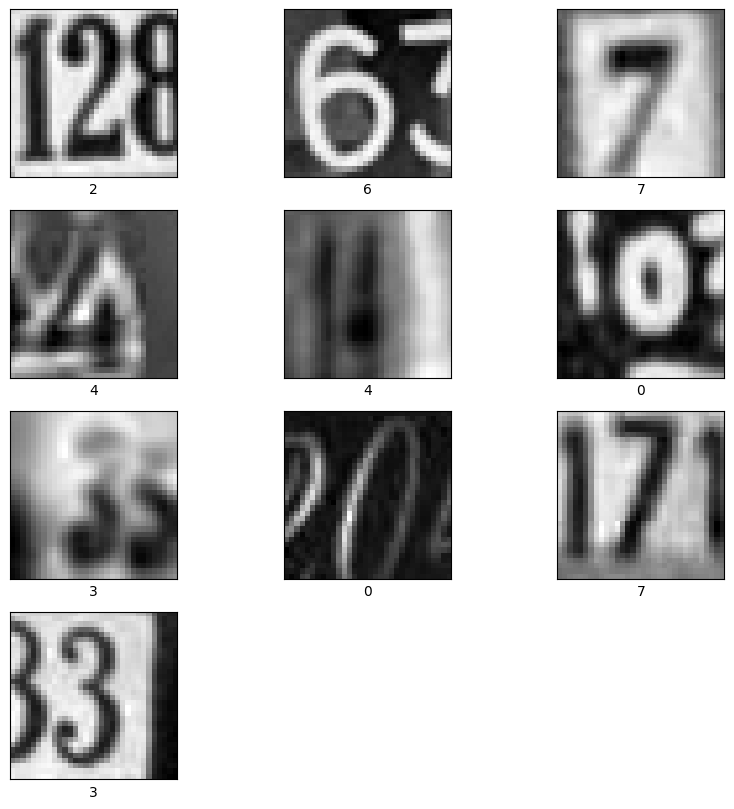

```python
#Plot a few training images and their assigned classification from the training data set
plt.figure(figsize= (10,10))
for i in range(10):
  plt.subplot(4,3,i+1)
  plt.xticks([])
  plt.yticks([])
  plt.grid(False)
  plt.imshow(x_train[i],cmap=plt.cm.binary)
  plt.xlabel(unique_categories_list[y_train[i]])
plt.show()
```

## **Data preparation**

- Print the shape and the array of pixels for the first image in the training dataset.
- Normalize the train and the test dataset by dividing by 255.
- Print the new shapes of the train and the test dataset.
- One-hot encode the target variable.

```python
#Print the shape for the first image in the training data set
print(x_train[0].shape)
```

```
(32, 32)
```

```python
#Print the first pixel of the first image
print(x_train[0][0,0])
```

```
33.0704
```

Print the array of pixels for the first image in the data set

```python
print(x_train[0])
```

```
[[ 33.0704  30.2601  26.852  ...  71.4471  58.2204  42.9939]
 [ 25.2283  25.5533  29.9765 ... 113.0209 103.3639  84.2949]
 [ 26.2775  22.6137  40.4763 ... 113.3028 121.775  115.4228]
 ...
 [ 28.5502  36.212   45.0801 ...  24.1359  25.0927  26.0603]
 [ 38.4352  26.4733  23.2717 ...  28.1094  29.4683  30.0661]
 [ 50.2984  26.0773  24.0389 ...  49.6682  50.853   53.0377]]
```

### **Normalize the train and the test data**

```python
#Normalize the train and test dataset
x_train = x_train/255
x_test = x_test/255
```

Print the shapes of Training and Test data after normalization

```python
print(x_train.shape)
print(x_test.shape)
```

```
(42000, 32, 32)
(18000, 32, 32)
```

Print the array of values for the first image after normalization

```python
print(x_train[0])
```

```
[[0.12968785 0.11866706 0.10530196 ... 0.2801847  0.2283153  0.16860352]
 [0.09893451 0.10020902 0.1175549  ... 0.4432192  0.40534863 0.33056822]
 [0.10304902 0.08868118 0.15873058 ... 0.44432473 0.47754902 0.45263842]
 ...
 [0.11196157 0.14200786 0.17678471 ... 0.09465059 0.09840274 0.10219726]
 [0.15072627 0.10381687 0.09126157 ... 0.11023294 0.11556196 0.11790627]
 [0.19724864 0.10226392 0.0942702  ... 0.19477727 0.19942354 0.20799099]]
```

### **One-hot encode output**

```python
Y_train = tf.keras.utils.to_categorical(y_train, num_classes = 10)
Y_test = tf.keras.utils.to_categorical(y_test, num_classes = 10)

#Examine shapes of the target variable after one hot encoding
print(Y_train.shape)
print(Y_test.shape)
```

```
(42000, 10)
(18000, 10)
```

```python
#Print the original classification label and one hot encoding of the first entry in the training data set
print("Digit",y_train[0], "is encoded as",Y_train[0])
```

```
Digit 2 is encoded as [0. 0. 1. 0. 0. 0. 0. 0. 0. 0.]
```

**Observations:**

## **Model Building**

Now that we have done the data preprocessing, let's build an ANN model.

### Fix the seed for random number generators

```python
tf.random.set_seed(42)
```

### **Model Architecture**

- Write a function that returns a sequential model with the following architecture:
- First hidden layer with **64 nodes and the relu activation** and the **input shape = (1024, )**
- Second hidden layer with **32 nodes and the relu activation**
- Output layer with **activation as 'softmax' and number of nodes equal to the number of classes, i.e., 10**
- Compile the model with the **loss equal to categorical_crossentropy, optimizer equal to Adam(learning_rate = 0.001), and metric equal to 'accuracy'**. Do not fit the model here, just return the compiled model.
- Call the nn_model_1 function and store the model in a new variable.
- Print the summary of the model.
- Fit on the train data with a **validation split of 0.2, batch size = 128, verbose = 1, and epochs = 20**. Store the model building history to use later for visualization.

```python
#Function to create first ANN model
def nn_model_1():
  model = Sequential([
      #Flatten image input layer
      Flatten(input_shape=(32,32,1)),

      #Dense and hidden and fully connected layers
      Dense(64, activation = 'relu'),
      Dense(32, activation = 'relu'),

      #classifier
      Dense(10, activation = 'softmax')
  ])

  model.compile(optimizer = Adam(learning_rate=0.001),
                loss = 'categorical_crossentropy',
                metrics = ['accuracy'])
  return model
```

Call the nn_model_1 function and store the model in a new variable.

```python
#Clear backend and print first ANN model summary
from tensorflow.keras import backend as K
K.clear_session()
tf.random.set_seed(42)

ann_model_1 = nn_model_1()

ann_model_1.summary()
```

```
Model: "sequential"
```

```
┏━━━━━━━━━━━━━━━━━━━━━━━━━━━━━━━━━━━━━━┳━━━━━━━━━━━━━━━━━━━━━━━━━━━━━┳━━━━━━━━━━━━━━━━━┓
┃ Layer (type)                         ┃ Output Shape                ┃         Param # ┃
┡━━━━━━━━━━━━━━━━━━━━━━━━━━━━━━━━━━━━━━╇━━━━━━━━━━━━━━━━━━━━━━━━━━━━━╇━━━━━━━━━━━━━━━━━┩
│ flatten (Flatten)                    │ (None, 1024)                │               0 │
├──────────────────────────────────────┼─────────────────────────────┼─────────────────┤
│ dense (Dense)                        │ (None, 64)                  │          65,600 │
├──────────────────────────────────────┼─────────────────────────────┼─────────────────┤
│ dense_1 (Dense)                      │ (None, 32)                  │           2,080 │
├──────────────────────────────────────┼─────────────────────────────┼─────────────────┤
│ dense_2 (Dense)                      │ (None, 10)                  │             330 │
└──────────────────────────────────────┴─────────────────────────────┴─────────────────┘
```

```
 Total params: 68,010 (265.66 KB)
```

```
 Trainable params: 68,010 (265.66 KB)
```

```
 Non-trainable params: 0 (0.00 B)
```

#### Observations

1. The number of parameters at the first layer after the flatten input section is (1024 * 64 + 64) = 65600. 1024 comes from images with 32 x 32 pixels.
2. The number of parameters the next layer is (64 * 32 + 32) = 2080
3. The number of parameters at the final layer is (32*10+10) = 330

### **Build and train an ANN model as per the above mentioned architecture.**

```python
#fit the model
fit_history_1 = ann_model_1.fit(x_train, Y_train, validation_split = 0.2, batch_size = 128, verbose=1, epochs=20)
```

```
263/263 ━━━━━━━━━━━━━━━━━━━━ 3s 5ms/step - accuracy: 0.1033 - loss: 2.3155 - val_accuracy: 0.1440 - val_loss: 2.2870
263/263 ━━━━━━━━━━━━━━━━━━━━ 2s 4ms/step - accuracy: 0.1414 - loss: 2.2546 - val_accuracy: 0.2682 - val_loss: 2.1109
263/263 ━━━━━━━━━━━━━━━━━━━━ 1s 4ms/step - accuracy: 0.2769 - loss: 2.0381 - val_accuracy: 0.3723 - val_loss: 1.8690
263/263 ━━━━━━━━━━━━━━━━━━━━ 1s 4ms/step - accuracy: 0.3807 - loss: 1.8113 - val_accuracy: 0.4432 - val_loss: 1.6700
263/263 ━━━━━━━━━━━━━━━━━━━━ 1s 4ms/step - accuracy: 0.4519 - loss: 1.6373 - val_accuracy: 0.5204 - val_loss: 1.4985
263/263 ━━━━━━━━━━━━━━━━━━━━ 1s 4ms/step - accuracy: 0.5233 - loss: 1.4760 - val_accuracy: 0.5806 - val_loss: 1.3428
263/263 ━━━━━━━━━━━━━━━━━━━━ 1s 4ms/step - accuracy: 0.5835 - loss: 1.3336 - val_accuracy: 0.6026 - val_loss: 1.2745
263/263 ━━━━━━━━━━━━━━━━━━━━ 2s 7ms/step - accuracy: 0.6056 - loss: 1.2699 - val_accuracy: 0.6177 - val_loss: 1.2357
263/263 ━━━━━━━━━━━━━━━━━━━━ 3s 8ms/step - accuracy: 0.6161 - loss: 1.2350 - val_accuracy: 0.6262 - val_loss: 1.2137
263/263 ━━━━━━━━━━━━━━━━━━━━ 2s 4ms/step - accuracy: 0.6233 - loss: 1.2114 - val_accuracy: 0.6300 - val_loss: 1.2032
263/263 ━━━━━━━━━━━━━━━━━━━━ 1s 4ms/step - accuracy: 0.6281 - loss: 1.1959 - val_accuracy: 0.6323 - val_loss: 1.1891
263/263 ━━━━━━━━━━━━━━━━━━━━ 1s 4ms/step - accuracy: 0.6324 - loss: 1.1825 - val_accuracy: 0.6352 - val_loss: 1.1846
263/263 ━━━━━━━━━━━━━━━━━━━━ 1s 4ms/step - accuracy: 0.6353 - loss: 1.1717 - val_accuracy: 0.6379 - val_loss: 1.1755
263/263 ━━━━━━━━━━━━━━━━━━━━ 1s 4ms/step - accuracy: 0.6403 - loss: 1.1611 - val_accuracy: 0.6415 - val_loss: 1.1643
263/263 ━━━━━━━━━━━━━━━━━━━━ 1s 4ms/step - accuracy: 0.6434 - loss: 1.1508 - val_accuracy: 0.6443 - val_loss: 1.1571
263/263 ━━━━━━━━━━━━━━━━━━━━ 1s 4ms/step - accuracy: 0.6454 - loss: 1.1427 - val_accuracy: 0.6495 - val_loss: 1.1418
263/263 ━━━━━━━━━━━━━━━━━━━━ 1s 4ms/step - accuracy: 0.6493 - loss: 1.1329 - val_accuracy: 0.6527 - val_loss: 1.1306
263/263 ━━━━━━━━━━━━━━━━━━━━ 2s 7ms/step - accuracy: 0.6509 - loss: 1.1226 - val_accuracy: 0.6560 - val_loss: 1.1182
263/263 ━━━━━━━━━━━━━━━━━━━━ 3s 7ms/step - accuracy: 0.6559 - loss: 1.1129 - val_accuracy: 0.6618 - val_loss: 1.1106
263/263 ━━━━━━━━━━━━━━━━━━━━ 1s 4ms/step - accuracy: 0.6588 - loss: 1.1039 - val_accuracy: 0.6635 - val_loss: 1.1051
```

#### Observations

1. The model accuracy increases with the number of epochs.
2. For 20 epochs, we have an accuracy of ~ 65.8% for the training and 66% for the validation data. This seems low.

### **Plot the Training and Validation Accuracies and write down your Observations.**

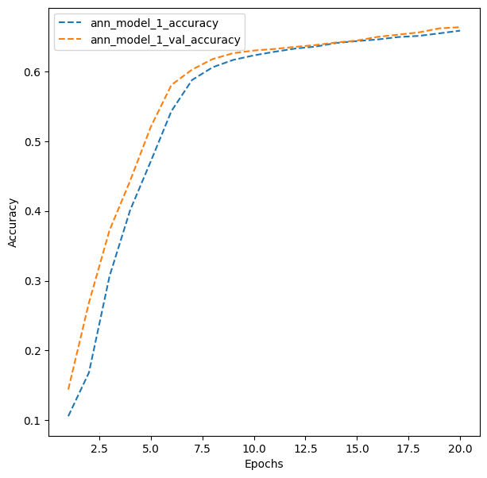

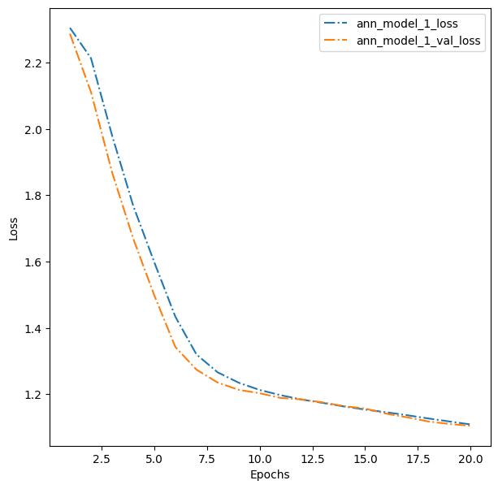

```python
#Plot training and validation accuracies and loss
dict_hist = fit_history_1.history

list_epoch = [i for i in range(1,21)]

plt.figure(figsize = (7,7))

plt.plot(list_epoch, dict_hist['accuracy'], ls = '--', label = 'ann_model_1_accuracy')
plt.plot(list_epoch, dict_hist['val_accuracy'], ls = '--', label = 'ann_model_1_val_accuracy')

plt.ylabel('Accuracy')
plt.xlabel('Epochs')
plt.legend()
plt.show()

plt.figure(figsize=(7,7))
plt.plot(list_epoch, dict_hist['loss'], ls = '-.', label = 'ann_model_1_loss')
plt.plot(list_epoch, dict_hist['val_loss'], ls = '-.', label = 'ann_model_1_val_loss')

plt.ylabel('Loss')
plt.xlabel('Epochs')
plt.legend()
plt.show()
```

**Observations:_______**

1. The training and validation accuracy increase with the same trend converging at a maximum accuracy of 66%
2. The training and validation loss decrease with the same trend, converging at a minumum of ~ 1.1

```python
#Define a method to evaluate model accuracy
def metrics_score(actual, predicted):
  from sklearn.metrics import classification_report
  from sklearn.metrics import confusion_matrix
  print(classification_report(actual, predicted))

  cm = confusion_matrix(actual, predicted)
  plt.figure(figsize=(7,7))
  sns.heatmap(cm, annot=True, fmt = '0.0f',
              xticklabels = unique_categories_list,
              yticklabels = unique_categories_list)
  plt.ylabel('Actual')
  plt.xlabel('Predicted')
  plt.show()
```

```python
#Evaluate model performance on test data
ann_model_1.evaluate(x_test, Y_test, verbose = 1)
ann_model_1_test_pred = np.argmax(ann_model_1.predict(x_test), axis=-1)
ann_model_1_test_pred
```

```
563/563 ━━━━━━━━━━━━━━━━━━━━ 1s 1ms/step - accuracy: 0.6659 - loss: 1.0874
563/563 ━━━━━━━━━━━━━━━━━━━━ 1s 1ms/step
```

```
array([0, 7, 2, ..., 7, 9, 2])
```

#### Observations

1. The accuracy on the test data is 66.5%, matching well with the accuracy observed in the training and validation data sets

```
              precision    recall  f1-score   support

           0       0.68      0.67      0.68      1814
           1       0.61      0.70      0.65      1828
           2       0.66      0.66      0.66      1803
           3       0.59      0.65      0.61      1719
           4       0.73      0.76      0.74      1812
           5       0.63      0.64      0.64      1768
           6       0.70      0.65      0.67      1832
           7       0.61      0.74      0.67      1808
           8       0.69      0.58      0.63      1812
           9       0.74      0.56      0.64      1804

    accuracy                           0.66     18000
   macro avg       0.66      0.66      0.66     18000
weighted avg       0.67      0.66      0.66     18000
```

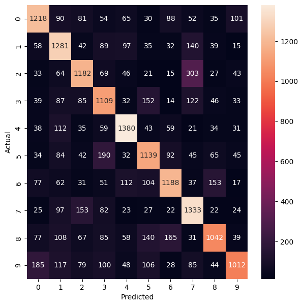

```python
#Publish the confusion matrix
metrics_score(y_test,ann_model_1_test_pred)
```

**Observations:_______**

1. For each class, a classification report shows the classification metrics - precision, recall, f1 score
2. Numbers 4 and 0 have the highest f1 scores. These numbers are often classified appropriately.
3. Numbers 3, 8, 5 and 9 have the lowest f1-scores. True number 8's are often misclassified as number 6's. True number 5's are misclassified as number 3's.
4. Actual number 7's can be misclassified as number 2's with high frequency.
5. Actual number 9's are misclassifies as number 0 also with high frequency.

Let's build one more model with higher complexity and see if we can improve the performance of the model.

First, we need to clear the previous model's history from the Keras backend. Also, let's fix the seed again after clearing the backend.

```python
#Clear previous model's history from the Keras backend
K.clear_session()
tf.random.set_seed(42)
```

### **Second Model Architecture**

- Write a function that returns a sequential model with the following architecture:
- First hidden layer with **256 nodes and the relu activation** and the **input shape = (1024, )**
- Second hidden layer with **128 nodes and the relu activation**
- Add the **Dropout layer with the rate equal to 0.2**
- Third hidden layer with **64 nodes and the relu activation**
- Fourth hidden layer with **64 nodes and the relu activation**
- Fifth hidden layer with **32 nodes and the relu activation**
- Add the **BatchNormalization layer**
- Output layer with **activation as 'softmax' and number of nodes equal to the number of classes, i.e., 10** -Compile the model with the **loss equal to categorical_crossentropy, optimizer equal to Adam(learning_rate = 0.0005), and metric equal to 'accuracy'**. Do not fit the model here, just return the compiled model.
- Call the nn_model_2 function and store the model in a new variable.
- Print the summary of the model.
- Fit on the train data with a **validation split of 0.2, batch size = 128, verbose = 1, and epochs = 30**. Store the model building history to use later for visualization.

### **Build and train the new ANN model as per the above mentioned architecture**

```python
#Function to create second ANN model
def nn_model_2():
  model = Sequential([
      #Flatten image input layer
      Flatten(input_shape=(32,32,1)),

      #Dense and hidden and fully connected layers
      Dense(256, activation = 'relu'),
      Dense(128, activation = 'relu'),
      Dropout(0.2),
      Dense(64, activation = 'relu'),
      Dense(64, activation = 'relu'),
      Dense(32, activation = 'relu'),
      BatchNormalization(),

      #classifier
      Dense(10, activation = 'softmax')
  ])

  model.compile(optimizer = Adam(learning_rate=0.0005),
                loss = 'categorical_crossentropy',
                metrics = ['accuracy'])
  return model
```

```python
#Publish second ANN summary
ann_model_2 = nn_model_2()

ann_model_2.summary()
```

```
Model: "sequential"
```

```
┏━━━━━━━━━━━━━━━━━━━━━━━━━━━━━━━━━━━━━━┳━━━━━━━━━━━━━━━━━━━━━━━━━━━━━┳━━━━━━━━━━━━━━━━━┓
┃ Layer (type)                         ┃ Output Shape                ┃         Param # ┃
┡━━━━━━━━━━━━━━━━━━━━━━━━━━━━━━━━━━━━━━╇━━━━━━━━━━━━━━━━━━━━━━━━━━━━━╇━━━━━━━━━━━━━━━━━┩
│ flatten (Flatten)                    │ (None, 1024)                │               0 │
├──────────────────────────────────────┼─────────────────────────────┼─────────────────┤
│ dense (Dense)                        │ (None, 256)                 │         262,400 │
├──────────────────────────────────────┼─────────────────────────────┼─────────────────┤
│ dense_1 (Dense)                      │ (None, 128)                 │          32,896 │
├──────────────────────────────────────┼─────────────────────────────┼─────────────────┤
│ dropout (Dropout)                    │ (None, 128)                 │               0 │
├──────────────────────────────────────┼─────────────────────────────┼─────────────────┤
│ dense_2 (Dense)                      │ (None, 64)                  │           8,256 │
├──────────────────────────────────────┼─────────────────────────────┼─────────────────┤
│ dense_3 (Dense)                      │ (None, 64)                  │           4,160 │
├──────────────────────────────────────┼─────────────────────────────┼─────────────────┤
│ dense_4 (Dense)                      │ (None, 32)                  │           2,080 │
├──────────────────────────────────────┼─────────────────────────────┼─────────────────┤
│ batch_normalization                  │ (None, 32)                  │             128 │
│ (BatchNormalization)                 │                             │                 │
├──────────────────────────────────────┼─────────────────────────────┼─────────────────┤
│ dense_5 (Dense)                      │ (None, 10)                  │             330 │
└──────────────────────────────────────┴─────────────────────────────┴─────────────────┘
```

```
 Total params: 310,250 (1.18 MB)
```

```
 Trainable params: 310,186 (1.18 MB)
```

```
 Non-trainable params: 64 (256.00 B)
```

#### Observations

1. The number of parameters at the first layer after the flatten input section is (1024 * 256 + 256) = 262400. 1024 comes from images with 32 x 32 pixels.
2. The number of parameters for the next layer is (256 * 128 + 128) = 32896
3. The dropout layer has no parameters
4. The number of parameters after the drop out layer is (128*64+64) = 8256
5. The number of parameters in the next layer is 64*64+64 = 4160
6. The number of parameters in the next layer is 64*32+32 = 2080
7. In the Batch Normalization layer, the number of parameters = 4 (2 trainable and 2 non-trainable parameters) * Number of features = 4 * 32 = 128
8. The classification layer has 32*10+10 = 330 parameters
9. Compared to the first model which has 68,010 parameters, the second model has 310,250 parameters. This is about a 4.5X increase in parameters. The second model will take longer to train but may result in increased accuracy.

```python
#fit the model
fit_history_2 = ann_model_2.fit(x_train, Y_train, validation_split = 0.2, batch_size = 128, verbose=1, epochs=30)
```

```
263/263 ━━━━━━━━━━━━━━━━━━━━ 5s 11ms/step - accuracy: 0.0993 - loss: 2.4202 - val_accuracy: 0.1135 - val_loss: 2.3036
263/263 ━━━━━━━━━━━━━━━━━━━━ 6s 14ms/step - accuracy: 0.1502 - loss: 2.2253 - val_accuracy: 0.2689 - val_loss: 2.0371
263/263 ━━━━━━━━━━━━━━━━━━━━ 4s 10ms/step - accuracy: 0.4088 - loss: 1.7051 - val_accuracy: 0.5646 - val_loss: 1.3769
263/263 ━━━━━━━━━━━━━━━━━━━━ 5s 10ms/step - accuracy: 0.5507 - loss: 1.3495 - val_accuracy: 0.6106 - val_loss: 1.2118
263/263 ━━━━━━━━━━━━━━━━━━━━ 7s 18ms/step - accuracy: 0.5977 - loss: 1.2204 - val_accuracy: 0.6346 - val_loss: 1.1331
263/263 ━━━━━━━━━━━━━━━━━━━━ 3s 11ms/step - accuracy: 0.6259 - loss: 1.1430 - val_accuracy: 0.6568 - val_loss: 1.0566
263/263 ━━━━━━━━━━━━━━━━━━━━ 3s 10ms/step - accuracy: 0.6564 - loss: 1.0715 - val_accuracy: 0.6644 - val_loss: 1.0464
263/263 ━━━━━━━━━━━━━━━━━━━━ 3s 10ms/step - accuracy: 0.6697 - loss: 1.0265 - val_accuracy: 0.6812 - val_loss: 1.0086
263/263 ━━━━━━━━━━━━━━━━━━━━ 4s 15ms/step - accuracy: 0.6826 - loss: 0.9833 - val_accuracy: 0.6977 - val_loss: 0.9652
263/263 ━━━━━━━━━━━━━━━━━━━━ 4s 16ms/step - accuracy: 0.6937 - loss: 0.9515 - val_accuracy: 0.7144 - val_loss: 0.8977
263/263 ━━━━━━━━━━━━━━━━━━━━ 3s 10ms/step - accuracy: 0.7096 - loss: 0.9112 - val_accuracy: 0.7127 - val_loss: 0.9153
263/263 ━━━━━━━━━━━━━━━━━━━━ 3s 11ms/step - accuracy: 0.7127 - loss: 0.8957 - val_accuracy: 0.7287 - val_loss: 0.8610
263/263 ━━━━━━━━━━━━━━━━━━━━ 3s 11ms/step - accuracy: 0.7166 - loss: 0.8780 - val_accuracy: 0.7361 - val_loss: 0.8387
263/263 ━━━━━━━━━━━━━━━━━━━━ 4s 16ms/step - accuracy: 0.7308 - loss: 0.8505 - val_accuracy: 0.7314 - val_loss: 0.8412
263/263 ━━━━━━━━━━━━━━━━━━━━ 3s 12ms/step - accuracy: 0.7356 - loss: 0.8306 - val_accuracy: 0.7469 - val_loss: 0.8029
263/263 ━━━━━━━━━━━━━━━━━━━━ 5s 10ms/step - accuracy: 0.7352 - loss: 0.8270 - val_accuracy: 0.7479 - val_loss: 0.8024
263/263 ━━━━━━━━━━━━━━━━━━━━ 3s 10ms/step - accuracy: 0.7421 - loss: 0.8132 - val_accuracy: 0.7590 - val_loss: 0.7809
263/263 ━━━━━━━━━━━━━━━━━━━━ 4s 17ms/step - accuracy: 0.7419 - loss: 0.8054 - val_accuracy: 0.7602 - val_loss: 0.7676
263/263 ━━━━━━━━━━━━━━━━━━━━ 3s 10ms/step - accuracy: 0.7515 - loss: 0.7804 - val_accuracy: 0.7463 - val_loss: 0.8161
263/263 ━━━━━━━━━━━━━━━━━━━━ 3s 10ms/step - accuracy: 0.7497 - loss: 0.7903 - val_accuracy: 0.7588 - val_loss: 0.7659
263/263 ━━━━━━━━━━━━━━━━━━━━ 3s 10ms/step - accuracy: 0.7593 - loss: 0.7567 - val_accuracy: 0.7511 - val_loss: 0.7845
263/263 ━━━━━━━━━━━━━━━━━━━━ 7s 17ms/step - accuracy: 0.7588 - loss: 0.7592 - val_accuracy: 0.7576 - val_loss: 0.7769
263/263 ━━━━━━━━━━━━━━━━━━━━ 3s 10ms/step - accuracy: 0.7631 - loss: 0.7512 - val_accuracy: 0.7525 - val_loss: 0.7832
263/263 ━━━━━━━━━━━━━━━━━━━━ 5s 10ms/step - accuracy: 0.7651 - loss: 0.7428 - val_accuracy: 0.7654 - val_loss: 0.7417
263/263 ━━━━━━━━━━━━━━━━━━━━ 4s 15ms/step - accuracy: 0.7674 - loss: 0.7297 - val_accuracy: 0.7655 - val_loss: 0.7456
263/263 ━━━━━━━━━━━━━━━━━━━━ 4s 15ms/step - accuracy: 0.7684 - loss: 0.7189 - val_accuracy: 0.7671 - val_loss: 0.7485
263/263 ━━━━━━━━━━━━━━━━━━━━ 3s 11ms/step - accuracy: 0.7709 - loss: 0.7187 - val_accuracy: 0.7644 - val_loss: 0.7422
263/263 ━━━━━━━━━━━━━━━━━━━━ 5s 10ms/step - accuracy: 0.7674 - loss: 0.7230 - val_accuracy: 0.7751 - val_loss: 0.7237
263/263 ━━━━━━━━━━━━━━━━━━━━ 6s 16ms/step - accuracy: 0.7727 - loss: 0.7056 - val_accuracy: 0.7655 - val_loss: 0.7602
263/263 ━━━━━━━━━━━━━━━━━━━━ 4s 10ms/step - accuracy: 0.7755 - loss: 0.7025 - val_accuracy: 0.7658 - val_loss: 0.7462
```

#### Observations

1. The model accuracy increases with the number of epochs.
2. For 30 epochs, we have an accuracy of 77.6% for the training and 76.6% for the validation data.
3. This more a complex model compared to the first ANN and it gives a higher accuracy for training and validation ~76% compared to the training and validation of the first simpler ANN model which was ~ 66%
4. The second ANN model is more complex, so the trade-off that one makes for the higher accuracy in model prediction is the need for more compute resources and longer training time.

### **Plot the Training and Validation Accuracies and write down your Observations.**

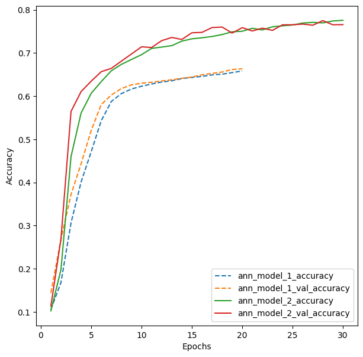

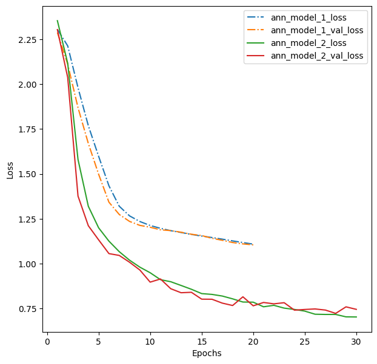

```python
#Plot training and validation accuracies and loss
dict_hist_2 = fit_history_2.history

list_epoch = [i for i in range(1,21)]
list_epoch_2 = [i for i in range(1,31)]

plt.figure(figsize = (7,7))

plt.plot(list_epoch, dict_hist['accuracy'], ls = '--', label = 'ann_model_1_accuracy')
plt.plot(list_epoch, dict_hist['val_accuracy'], ls = '--', label = 'ann_model_1_val_accuracy')
plt.plot(list_epoch_2, dict_hist_2['accuracy'], label = 'ann_model_2_accuracy')
plt.plot(list_epoch_2, dict_hist_2['val_accuracy'], label = 'ann_model_2_val_accuracy')

plt.ylabel('Accuracy')
plt.xlabel('Epochs')
plt.legend()
plt.show()

plt.figure(figsize=(7,7))
plt.plot(list_epoch, dict_hist['loss'], ls = '-.', label = 'ann_model_1_loss')
plt.plot(list_epoch, dict_hist['val_loss'], ls = '-.', label = 'ann_model_1_val_loss')
plt.plot(list_epoch_2, dict_hist_2['loss'], label = 'ann_model_2_loss')
plt.plot(list_epoch_2, dict_hist_2['val_loss'], label = 'ann_model_2_val_loss')

plt.ylabel('Loss')
plt.xlabel('Epochs')
plt.legend()
plt.show()
```

**Observations:_______**

1. The second more complex ANN model has higher accuracy ~76% compared to the first simpler model which had an accuracy of 66%
2. There is good convergence and alignment in accuracy trends between the training and validation trends for the two models.
3. The second more complex ANN model achieves a lower loss compared to the first simpler ANN model.
4. More epochs allowed the second model to continue increasing accuracy.

## **Predictions on the test data**

- Make predictions on the test set using the second model.
- Print the obtained results using the classification report and the confusion matrix.
- Final observations on the obtained results.

```python
#Evaluate model accuracy on test data
ann_model_2.evaluate(x_test, Y_test, verbose = 1)
ann_model_2_test_pred = np.argmax(ann_model_2.predict(x_test), axis=-1)
ann_model_2_test_pred
```

```
563/563 ━━━━━━━━━━━━━━━━━━━━ 1s 2ms/step - accuracy: 0.7668 - loss: 0.7474
563/563 ━━━━━━━━━━━━━━━━━━━━ 1s 2ms/step
```

```
array([8, 2, 2, ..., 7, 9, 2])
```

#### Observations

1. The accuracy on the test data is 76.7%, matching well with the accuracy observed in the training and validation data sets

### **Print the classification report and the confusion matrix for the test predictions. Write your observations on the final results.**

**Note:** Earlier, we noticed that each entry of the target variable is a one-hot encoded vector but to print the classification report and confusion matrix, we must convert each entry of y_test to a single label.

```
              precision    recall  f1-score   support

           0       0.79      0.79      0.79      1814
           1       0.73      0.82      0.77      1828
           2       0.74      0.81      0.77      1803
           3       0.68      0.75      0.71      1719
           4       0.85      0.80      0.83      1812
           5       0.79      0.68      0.73      1768
           6       0.84      0.73      0.78      1832
           7       0.79      0.80      0.80      1808
           8       0.69      0.74      0.71      1812
           9       0.79      0.74      0.76      1804

    accuracy                           0.76     18000
   macro avg       0.77      0.76      0.76     18000
weighted avg       0.77      0.76      0.77     18000
```

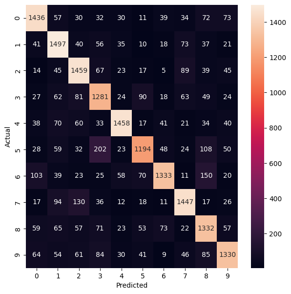

```python
#Publish the confusion matrix
metrics_score(y_test,ann_model_2_test_pred)
```

**Final Observations:__________**

1. The second model shows better performance for number classification accuracy. The second model has an accuracy of 76% compared to an accuracy of ~66% for the first model.
2. We observe better prediction for all the digits, the diagonal shows much higher numbers for every digit
3. Similar to the first model, numbers 8, 5, and 3 show the lowest f1-scores. True number 8's are often misclassified as 6. True number 5's are misclassified as 3. True number 3's are misclassified as 5 or 2.
4. Number's 0, 4, and 7 have the highest f1-scores
5. Both models struggle to classify digits 8, 5, and 3 correctly.
6. The matching of training, validation, and test accuracy show that the models are not overfitting on train data.

#### Let us visualize 24 images from the test data and their classification

[output not shown]

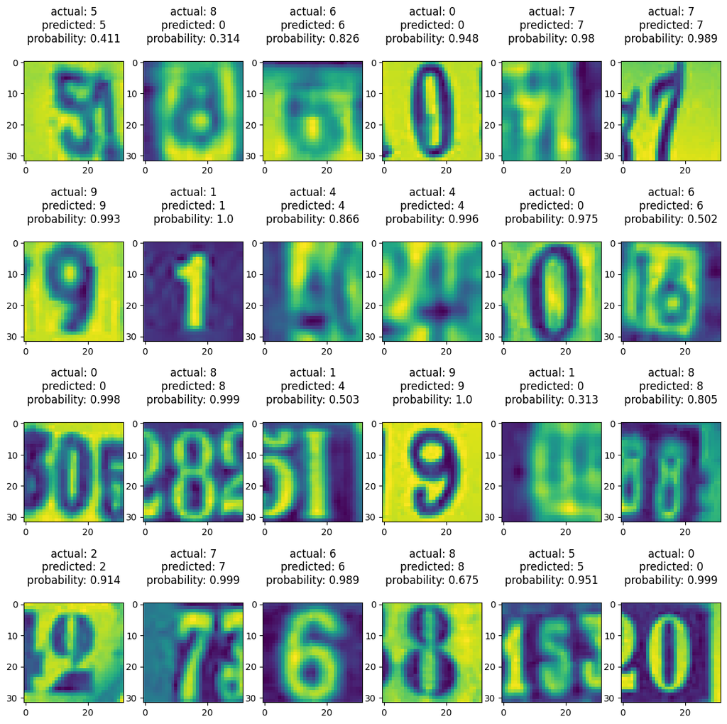

```python
#Visualize images from the test data, their true values and the classification by the model
rows = 4
cols = 6

fig = plt.figure(figsize=(14,14))
for i in range(cols):
  for j in range(rows):
    random_index = np.random.randint(0, len(Y_test))
    ax = fig.add_subplot(rows,cols,i*rows+j+1)
    ax.imshow(x_test[random_index,:])
    pred_label = unique_categories_list[ann_model_2_test_pred[random_index]]
    true_label = unique_categories_list[y_test[random_index]]
    y_pred_test_model_2_max_probas = np.max(ann_model_2.predict(x_test), axis=1)
    pred_proba = y_pred_test_model_2_max_probas[random_index]

    ax.set_title("actual: {}\npredicted: {}\nprobability: {:.3}\n".format(
        true_label, pred_label, pred_proba
    ))

plt.show()
```

#### Observations

1. The second fully connected artificial neural network model does a fairly good job classifying the numbers. However, there are some mistakes.
2. Of the 2 models trained so far, the second artificial neural networks provides the highest accuracy for street level digit recognition. The trade-off is that this model takes longer to train.

## **Using Convolutional Neural Networks**

### **Load the dataset again and split the data into the train and the test dataset.**

```python
#Load the datasets for training, validation, and test
with h5py.File(file_path, "r") as h5_file:
  x_train = h5_file["X_train"][:]
  y_train = h5_file["y_train"][:]
  x_test = h5_file["X_test"][:]
  y_test = h5_file["y_test"][:]
```

Check the number of images in the training and the testing dataset.

```python
#Check the shape of the datasets
print("x_train shape:", x_train.shape)
print("y_train shape:", y_train.shape)
print("x_test shape:", x_test.shape)
print("y_test shape:", y_test.shape)
```

```
x_train shape: (42000, 32, 32)
y_train shape: (42000,)
x_test shape: (18000, 32, 32)
y_test shape: (18000,)
```

**Observation:**

1. There are 42000 training images with dimensions 32 X 32 pixels. This is 70% of the data set.
2. There are 18000 testing images with dimensions 32 X 32 pixels. This is 30% of the data set.
3. The digits are classified in the y data sets, y_train has 42000 entries while y_test as 18000 entries.

## **Data preparation**

- Print the shape and the array of pixels for the first image in the training dataset.
- Reshape the train and the test dataset because we always have to give a 4D array as input to CNNs.
- Normalize the train and the test dataset by dividing by 255.
- Print the new shapes of the train and the test dataset.
- One-hot encode the target variable.

```python
#Print the shape for the first image in the training dataset.
print(x_train[0].shape)
```

```
(32, 32)
```

```python
#Print the array of pixels for the first image in the training dataset.
print(x_train[0])
```

```
[[ 33.0704  30.2601  26.852  ...  71.4471  58.2204  42.9939]
 [ 25.2283  25.5533  29.9765 ... 113.0209 103.3639  84.2949]
 [ 26.2775  22.6137  40.4763 ... 113.3028 121.775  115.4228]
 ...
 [ 28.5502  36.212   45.0801 ...  24.1359  25.0927  26.0603]
 [ 38.4352  26.4733  23.2717 ...  28.1094  29.4683  30.0661]
 [ 50.2984  26.0773  24.0389 ...  49.6682  50.853   53.0377]]
```

Normalize inputs from 0-255 to 0-1

```python
#Normalize the train and the test dataset by dividing by 255.
x_train = x_train/255
x_test = x_test/255
```

Reshape the dataset to be able to pass them to CNNs. Remember that we always have to give a 4D array as input to CNNs

```python
#Reshape the train and the test dataset because we always have to give a 4D array as input to CNNs.
X_train = x_train.reshape(42000, 32, 32, 1)
X_test = x_test.reshape(18000, 32, 32, 1)
```

Print New shape of Training and Test

```python
#Check the shape of the datasets
print("X_train shape:", X_train.shape)
print("x_train shape:", x_train.shape)
print("y_train shape:", y_train.shape)
print("X_test shape:", X_test.shape)
print("x_test shape:", x_test.shape)
print("y_test shape:", y_test.shape)
```

```
X_train shape: (42000, 32, 32, 1)
x_train shape: (42000, 32, 32)
y_train shape: (42000,)
X_test shape: (18000, 32, 32, 1)
x_test shape: (18000, 32, 32)
y_test shape: (18000,)
```

### **One-hot encode the labels in the target variable y_train and y_test.**

```python
#One-hot encode the target variable.
Y_train = tf.keras.utils.to_categorical(y_train)
Y_test = tf.keras.utils.to_categorical(y_test)
```

```python
#Print the original classification label and one hot encoding of the first entry in the training data set
print("Digit",y_train[0], "is encoded as",Y_train[0])
```

```
Digit 2 is encoded as [0. 0. 1. 0. 0. 0. 0. 0. 0. 0.]
```

**Observation:**

## **Model Building**

Now that we have done data preprocessing, let's build a CNN model. Fix the seed for random number generators

```python
#Clear previous model's history from the Keras backend and fix the random number generator seed
K.clear_session()
tf.random.set_seed(42)
```

### **Model Architecture**

- **Write a function** that returns a sequential model with the following architecture:
- First Convolutional layer with **16 filters and the kernel size of 3x3**. Use the **'same' padding** and provide the **input shape = (32, 32, 1)**
- Add a **LeakyRelu layer** with the **slope equal to 0.1**
- Second Convolutional layer with **32 filters and the kernel size of 3x3 with 'same' padding**
- Another **LeakyRelu** with the **slope equal to 0.1**
- A **max-pooling layer** with a **pool size of 2x2**
- **Flatten** the output from the previous layer
- Add a **dense layer with 32 nodes**
- Add a **LeakyRelu layer with the slope equal to 0.1**
- Add the final **output layer with nodes equal to the number of classes, i.e., 10** and **'softmax' as the activation function**
- Compile the model with the **loss equal to categorical_crossentropy, optimizer equal to Adam(learning_rate = 0.001), and metric equal to 'accuracy'**. Do not fit the model here, just return the compiled model.
- Call the function cnn_model_1 and store the output in a new variable.
- Print the summary of the model.
- Fit the model on the training data with a **validation split of 0.2, batch size = 32, verbose = 1, and epochs = 20**. Store the model building history to use later for visualization.

```python
#Define function to create a convolutional neural network model
def cnn_model_1():
  model = Sequential()
  #Two convolutional layers and a max-pooling layer
  model.add(Conv2D(filters=16, kernel_size=(3,3), padding = 'same', input_shape=(32,32,1)))
  model.add(LeakyReLU(alpha=0.1))
  model.add(Conv2D(filters=32, kernel_size=(3,3), padding = 'same'))
  model.add(LeakyReLU(alpha=0.1))
  model.add(MaxPooling2D(pool_size = (2,2)))
  #Flattening the data to make room for the fully connected component
  model.add(Flatten())
  #Add layers for fully connected component
  model.add(Dense(32))
  model.add(LeakyReLU(alpha=0.1))
  model.add(Dense(10, activation = 'softmax'))
  model.compile(optimizer = Adam(learning_rate=0.001),
                loss = 'categorical_crossentropy',
                metrics = ['accuracy'])
  return model
```

```python
#Publish first CNN model summary
cnn_model_1 = cnn_model_1()

cnn_model_1.summary()
```

```
Model: "sequential"
```

```
┏━━━━━━━━━━━━━━━━━━━━━━━━━━━━━━━━━━━━━━┳━━━━━━━━━━━━━━━━━━━━━━━━━━━━━┳━━━━━━━━━━━━━━━━━┓
┃ Layer (type)                         ┃ Output Shape                ┃         Param # ┃
┡━━━━━━━━━━━━━━━━━━━━━━━━━━━━━━━━━━━━━━╇━━━━━━━━━━━━━━━━━━━━━━━━━━━━━╇━━━━━━━━━━━━━━━━━┩
│ conv2d (Conv2D)                      │ (None, 32, 32, 16)          │             160 │
├──────────────────────────────────────┼─────────────────────────────┼─────────────────┤
│ leaky_re_lu (LeakyReLU)              │ (None, 32, 32, 16)          │               0 │
├──────────────────────────────────────┼─────────────────────────────┼─────────────────┤
│ conv2d_1 (Conv2D)                    │ (None, 32, 32, 32)          │           4,640 │
├──────────────────────────────────────┼─────────────────────────────┼─────────────────┤
│ leaky_re_lu_1 (LeakyReLU)            │ (None, 32, 32, 32)          │               0 │
├──────────────────────────────────────┼─────────────────────────────┼─────────────────┤
│ max_pooling2d (MaxPooling2D)         │ (None, 16, 16, 32)          │               0 │
├──────────────────────────────────────┼─────────────────────────────┼─────────────────┤
│ flatten (Flatten)                    │ (None, 8192)                │               0 │
├──────────────────────────────────────┼─────────────────────────────┼─────────────────┤
│ dense (Dense)                        │ (None, 32)                  │         262,176 │
├──────────────────────────────────────┼─────────────────────────────┼─────────────────┤
│ leaky_re_lu_2 (LeakyReLU)            │ (None, 32)                  │               0 │
├──────────────────────────────────────┼─────────────────────────────┼─────────────────┤
│ dense_1 (Dense)                      │ (None, 10)                  │             330 │
└──────────────────────────────────────┴─────────────────────────────┴─────────────────┘
```

```
 Total params: 267,306 (1.02 MB)
```

```
 Trainable params: 267,306 (1.02 MB)
```

```
 Non-trainable params: 0 (0.00 B)
```

#### Observations

- The model has:
1. The first convolutional layer of the CNN has 16(filters) x (3 x 3 x 1) + 16 parameters = 160. Padding is 'same' so the input and output size are matched.
2. The LeakyReLU layer applies an element-wise activation function to the input and has no learnable parameters.
3. The second convolutional layer has 32 x (3 x 3 x 16) + 32 parameters = 4640
4. The max pooling layer of size (2,2) is applied on the output of the second convolutional layer.
5. The flatten layer collapses to 32 x 16 x 16 inputs = 8192
6. The dense layer has 8192 x 32 + 32 = 262,176 parameters to train. This layer has 32 nodes.
7. The final classification layer has 32 x 10 + 10 parameters = 330

### **Build and train a CNN model as per the above mentioned architecture.**

```python
#fit the model
fit_history_3 = cnn_model_1.fit(X_train, Y_train, validation_split = 0.2, batch_size = 32, verbose=1, epochs=20)
```

```
1050/1050 ━━━━━━━━━━━━━━━━━━━━ 75s 70ms/step - accuracy: 0.3930 - loss: 1.7041 - val_accuracy: 0.8187 - val_loss: 0.6379
1050/1050 ━━━━━━━━━━━━━━━━━━━━ 72s 68ms/step - accuracy: 0.8298 - loss: 0.5822 - val_accuracy: 0.8357 - val_loss: 0.5738
1050/1050 ━━━━━━━━━━━━━━━━━━━━ 84s 70ms/step - accuracy: 0.8622 - loss: 0.4769 - val_accuracy: 0.8545 - val_loss: 0.5179
1050/1050 ━━━━━━━━━━━━━━━━━━━━ 72s 68ms/step - accuracy: 0.8805 - loss: 0.4059 - val_accuracy: 0.8635 - val_loss: 0.4925
1050/1050 ━━━━━━━━━━━━━━━━━━━━ 74s 70ms/step - accuracy: 0.8988 - loss: 0.3509 - val_accuracy: 0.8594 - val_loss: 0.5029
1050/1050 ━━━━━━━━━━━━━━━━━━━━ 82s 70ms/step - accuracy: 0.9110 - loss: 0.3086 - val_accuracy: 0.8652 - val_loss: 0.4942
1050/1050 ━━━━━━━━━━━━━━━━━━━━ 86s 74ms/step - accuracy: 0.9222 - loss: 0.2739 - val_accuracy: 0.8688 - val_loss: 0.5031
1050/1050 ━━━━━━━━━━━━━━━━━━━━ 84s 76ms/step - accuracy: 0.9300 - loss: 0.2448 - val_accuracy: 0.8699 - val_loss: 0.5243
1050/1050 ━━━━━━━━━━━━━━━━━━━━ 77s 71ms/step - accuracy: 0.9372 - loss: 0.2183 - val_accuracy: 0.8689 - val_loss: 0.5578
1050/1050 ━━━━━━━━━━━━━━━━━━━━ 73s 69ms/step - accuracy: 0.9404 - loss: 0.1997 - val_accuracy: 0.8650 - val_loss: 0.6095
1050/1050 ━━━━━━━━━━━━━━━━━━━━ 84s 71ms/step - accuracy: 0.9472 - loss: 0.1763 - val_accuracy: 0.8600 - val_loss: 0.6201
1050/1050 ━━━━━━━━━━━━━━━━━━━━ 82s 71ms/step - accuracy: 0.9524 - loss: 0.1570 - val_accuracy: 0.8469 - val_loss: 0.7037
1050/1050 ━━━━━━━━━━━━━━━━━━━━ 87s 76ms/step - accuracy: 0.9549 - loss: 0.1464 - val_accuracy: 0.8463 - val_loss: 0.7195
1050/1050 ━━━━━━━━━━━━━━━━━━━━ 81s 77ms/step - accuracy: 0.9546 - loss: 0.1418 - val_accuracy: 0.8373 - val_loss: 0.7871
1050/1050 ━━━━━━━━━━━━━━━━━━━━ 86s 81ms/step - accuracy: 0.9580 - loss: 0.1289 - val_accuracy: 0.8348 - val_loss: 0.8396
1050/1050 ━━━━━━━━━━━━━━━━━━━━ 141s 79ms/step - accuracy: 0.9579 - loss: 0.1258 - val_accuracy: 0.8381 - val_loss: 0.8518
1050/1050 ━━━━━━━━━━━━━━━━━━━━ 174s 110ms/step - accuracy: 0.9626 - loss: 0.1130 - val_accuracy: 0.8498 - val_loss: 0.8567
1050/1050 ━━━━━━━━━━━━━━━━━━━━ 107s 77ms/step - accuracy: 0.9699 - loss: 0.0945 - val_accuracy: 0.8442 - val_loss: 0.8835
1050/1050 ━━━━━━━━━━━━━━━━━━━━ 94s 89ms/step - accuracy: 0.9679 - loss: 0.0959 - val_accuracy: 0.8489 - val_loss: 0.9196
1050/1050 ━━━━━━━━━━━━━━━━━━━━ 122s 71ms/step - accuracy: 0.9723 - loss: 0.0871 - val_accuracy: 0.8455 - val_loss: 0.9818
```

### **Plot the Training and Validation Accuracies and Write your observations.**

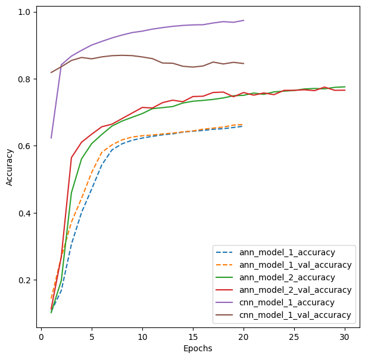

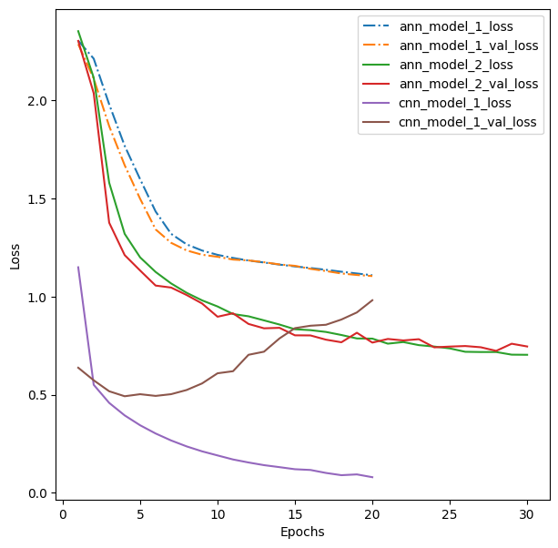

```python
#Plot training and validation accuracies and loss
dict_hist_3 = fit_history_3.history

list_epoch = [i for i in range(1,21)]
list_epoch_2 = [i for i in range(1,31)]

plt.figure(figsize = (7,7))

plt.plot(list_epoch, dict_hist['accuracy'], ls = '--', label = 'ann_model_1_accuracy')
plt.plot(list_epoch, dict_hist['val_accuracy'], ls = '--', label = 'ann_model_1_val_accuracy')
plt.plot(list_epoch_2, dict_hist_2['accuracy'], label = 'ann_model_2_accuracy')
plt.plot(list_epoch_2, dict_hist_2['val_accuracy'], label = 'ann_model_2_val_accuracy')
plt.plot(list_epoch, dict_hist_3['accuracy'], label = 'cnn_model_1_accuracy')
plt.plot(list_epoch, dict_hist_3['val_accuracy'], label = 'cnn_model_1_val_accuracy')

plt.ylabel('Accuracy')
plt.xlabel('Epochs')
plt.legend()
plt.show()

plt.figure(figsize=(7,7))
plt.plot(list_epoch, dict_hist['loss'], ls = '-.', label = 'ann_model_1_loss')
plt.plot(list_epoch, dict_hist['val_loss'], ls = '-.', label = 'ann_model_1_val_loss')
plt.plot(list_epoch_2, dict_hist_2['loss'], label = 'ann_model_2_loss')
plt.plot(list_epoch_2, dict_hist_2['val_loss'], label = 'ann_model_2_val_loss')
plt.plot(list_epoch, dict_hist_3['loss'], label = 'cnn_model_1_loss')
plt.plot(list_epoch, dict_hist_3['val_loss'], label = 'cnn_model_1_val_loss')

plt.ylabel('Loss')
plt.xlabel('Epochs')
plt.legend()
plt.show()
```

**Observations:__________**

1. The convolutional neural network has higher accuracy on the training data set compared to the artificial neural network models
2. On the training data set, accuracy keeps increasing to 97% value and the loss keeps decreasing. However, the model is **overfitting** and does not generalize well to the validation set. The validation accuracy plateaus and decreases slightly, while the validation loss starts increasing. We need to improve the model to prevent overfitting.
3. The convolutional neural network also takes much longer to train on my PC - Google collab. It runs for about 30 minutes.

## **Predictions on the test data for the first CNN model**

```python
#Evaluate model accuracy on test data
cnn_model_1.evaluate(X_test, Y_test, verbose = 1)
cnn_model_1_test_pred = np.argmax(cnn_model_1.predict(X_test), axis=-1)
cnn_model_1_test_pred
```

```
563/563 ━━━━━━━━━━━━━━━━━━━━ 10s 17ms/step - accuracy: 0.8503 - loss: 0.9256
563/563 ━━━━━━━━━━━━━━━━━━━━ 10s 18ms/step
```

```
array([1, 7, 2, ..., 7, 8, 2])
```

#### Observations

1. The prediction accuracy for the first convolutional neural network is 85%

### **Print the classification report and the confusion matrix for the test predictions from the first CNN model. Write your observations on the final results.**

```
              precision    recall  f1-score   support

           0       0.88      0.88      0.88      1814
           1       0.89      0.83      0.86      1828
           2       0.86      0.86      0.86      1803
           3       0.76      0.82      0.79      1719
           4       0.89      0.87      0.88      1812
           5       0.88      0.79      0.83      1768
           6       0.81      0.85      0.83      1832
           7       0.87      0.87      0.87      1808
           8       0.77      0.84      0.80      1812
           9       0.85      0.82      0.83      1804

    accuracy                           0.84     18000
   macro avg       0.85      0.84      0.84     18000
weighted avg       0.85      0.84      0.84     18000
```

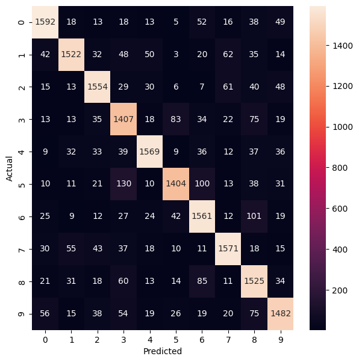

```python
#Publish the confusion matrix
metrics_score(y_test,cnn_model_1_test_pred)
```

#### Observations

1. The model accuracy of the first CNN is higher than the best ANN. Accuracy for the CNN is ~84%.
2. Numbers 3 and 8 have the lowest f1-scores. The ANN models also struggled to classify these digits.
3. Numbers 0, 4, and 7 have the highest f1-scores.
4. The first CNN is the best model so far in terms of accuracy. It is however slow to train and is overfitting on the training data set.

#### Let us visualize 24 images from the test data and their classification

[output not shown]

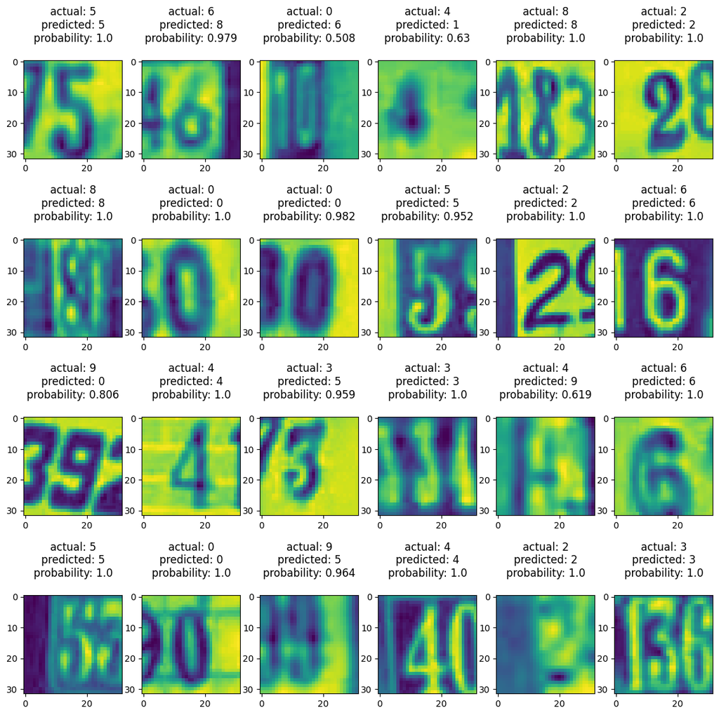

```python
#Visualize images from the test data, their true values and the classification by the model
rows = 4
cols = 6

fig = plt.figure(figsize=(14,14))
for i in range(cols):
  for j in range(rows):
    random_index = np.random.randint(0, len(Y_test))
    ax = fig.add_subplot(rows,cols,i*rows+j+1)
    ax.imshow(x_test[random_index,:])
    pred_label = unique_categories_list[cnn_model_1_test_pred[random_index]]
    true_label = unique_categories_list[y_test[random_index]]
    y_pred_test_cnn_model_1_max_probas = np.max(cnn_model_1.predict(X_test), axis=1)
    pred_proba = y_pred_test_cnn_model_1_max_probas[random_index]

    ax.set_title("actual: {}\npredicted: {}\nprobability: {:.3}\n".format(
        true_label, pred_label, pred_proba
    ))

plt.show()
```

Let's build another model and see if we can get a better model with generalized performance.

First, we need to clear the previous model's history from the Keras backend. Also, let's fix the seed again after clearing the backend.

```python
#Clear previous model's history from the Keras backend and fix the random number generator seed
K.clear_session()
tf.random.set_seed(42)
```

### **Second Model Architecture**

- Write a function that returns a sequential model with the following architecture:
- First Convolutional layer with **16 filters and the kernel size of 3x3**. Use the **'same' padding** and provide the **input shape = (32, 32, 1)**
- Add a **LeakyRelu layer** with the **slope equal to 0.1**
- Second Convolutional layer with **32 filters and the kernel size of 3x3 with 'same' padding**
- Add **LeakyRelu** with the **slope equal to 0.1**
- Add a **max-pooling layer** with a **pool size of 2x2**
- Add a **BatchNormalization layer**
- Third Convolutional layer with **32 filters and the kernel size of 3x3 with 'same' padding**
- Add a **LeakyRelu layer with the slope equal to 0.1**
- Fourth Convolutional layer **64 filters and the kernel size of 3x3 with 'same' padding**
- Add a **LeakyRelu layer with the slope equal to 0.1**
- Add a **max-pooling layer** with a **pool size of 2x2**
- Add a **BatchNormalization layer**
- **Flatten** the output from the previous layer
- Add a **dense layer with 32 nodes**
- Add a **LeakyRelu layer with the slope equal to 0.1**
- Add a **dropout layer with the rate equal to 0.5**
- Add the final **output layer with nodes equal to the number of classes, i.e., 10** and **'softmax' as the activation function**
- Compile the model with the **categorical_crossentropy loss, adam optimizers (learning_rate = 0.001), and metric equal to 'accuracy'**. Do not fit the model here, just return the compiled model.
- Call the function cnn_model_2 and store the model in a new variable.
- Print the summary of the model.
- Fit the model on the train data with a **validation split of 0.2, batch size = 128, verbose = 1, and epochs = 30**. Store the model building history to use later for visualization.

### **Build and train the second CNN model as per the above mentioned architecture.**

```python
#Define function to create a convolutional neural network model
def cnn_model_2():
  model = Sequential()
  #Two convolutional layers and a max-pooling layer
  model.add(Conv2D(filters=16, kernel_size=(3,3), padding = 'same', input_shape=(32,32,1)))
  model.add(LeakyReLU(alpha=0.1))
  model.add(Conv2D(filters=32, kernel_size=(3,3), padding = 'same'))
  model.add(LeakyReLU(alpha=0.1))
  model.add(MaxPooling2D(pool_size = (2,2)))
  #Add batch normalization layer
  model.add(BatchNormalization())
  #Add additional convolutional layers
  model.add(Conv2D(filters=32, kernel_size=(3,3), padding = 'same'))
  model.add(LeakyReLU(alpha=0.1))
  model.add(Conv2D(filters=64, kernel_size=(3,3), padding = 'same'))
  model.add(LeakyReLU(alpha=0.1))
  #Add max pooling layer
  model.add(MaxPooling2D(pool_size = (2,2)))
  #Add batch normalization layer
  model.add(BatchNormalization())
  #Flattening the data to make room for the fully connected component
  model.add(Flatten())
  #Add layers for fully connected component
  model.add(Dense(32))
  model.add(LeakyReLU(alpha=0.1))
  model.add(Dropout(0.5))
  model.add(Dense(10, activation = 'softmax'))
  model.compile(optimizer = Adam(learning_rate=0.001),
                loss = 'categorical_crossentropy',
                metrics = ['accuracy'])
  return model
```

```python
#Publish second CNN model summary
cnn_model_2 = cnn_model_2()

cnn_model_2.summary()
```

```
Model: "sequential"
```

```
┏━━━━━━━━━━━━━━━━━━━━━━━━━━━━━━━━━━━━━━┳━━━━━━━━━━━━━━━━━━━━━━━━━━━━━┳━━━━━━━━━━━━━━━━━┓
┃ Layer (type)                         ┃ Output Shape                ┃         Param # ┃
┡━━━━━━━━━━━━━━━━━━━━━━━━━━━━━━━━━━━━━━╇━━━━━━━━━━━━━━━━━━━━━━━━━━━━━╇━━━━━━━━━━━━━━━━━┩
│ conv2d (Conv2D)                      │ (None, 32, 32, 16)          │             160 │
├──────────────────────────────────────┼─────────────────────────────┼─────────────────┤
│ leaky_re_lu (LeakyReLU)              │ (None, 32, 32, 16)          │               0 │
├──────────────────────────────────────┼─────────────────────────────┼─────────────────┤
│ conv2d_1 (Conv2D)                    │ (None, 32, 32, 32)          │           4,640 │
├──────────────────────────────────────┼─────────────────────────────┼─────────────────┤
│ leaky_re_lu_1 (LeakyReLU)            │ (None, 32, 32, 32)          │               0 │
├──────────────────────────────────────┼─────────────────────────────┼─────────────────┤
│ max_pooling2d (MaxPooling2D)         │ (None, 16, 16, 32)          │               0 │
├──────────────────────────────────────┼─────────────────────────────┼─────────────────┤
│ batch_normalization                  │ (None, 16, 16, 32)          │             128 │
│ (BatchNormalization)                 │                             │                 │
├──────────────────────────────────────┼─────────────────────────────┼─────────────────┤
│ conv2d_2 (Conv2D)                    │ (None, 16, 16, 32)          │           9,248 │
├──────────────────────────────────────┼─────────────────────────────┼─────────────────┤
│ leaky_re_lu_2 (LeakyReLU)            │ (None, 16, 16, 32)          │               0 │
├──────────────────────────────────────┼─────────────────────────────┼─────────────────┤
│ conv2d_3 (Conv2D)                    │ (None, 16, 16, 64)          │          18,496 │
├──────────────────────────────────────┼─────────────────────────────┼─────────────────┤
│ leaky_re_lu_3 (LeakyReLU)            │ (None, 16, 16, 64)          │               0 │
├──────────────────────────────────────┼─────────────────────────────┼─────────────────┤
│ max_pooling2d_1 (MaxPooling2D)       │ (None, 8, 8, 64)            │               0 │
├──────────────────────────────────────┼─────────────────────────────┼─────────────────┤
│ batch_normalization_1                │ (None, 8, 8, 64)            │             256 │
│ (BatchNormalization)                 │                             │                 │
├──────────────────────────────────────┼─────────────────────────────┼─────────────────┤
│ flatten (Flatten)                    │ (None, 4096)                │               0 │
├──────────────────────────────────────┼─────────────────────────────┼─────────────────┤
│ dense (Dense)                        │ (None, 32)                  │         131,104 │
├──────────────────────────────────────┼─────────────────────────────┼─────────────────┤
│ leaky_re_lu_4 (LeakyReLU)            │ (None, 32)                  │               0 │
├──────────────────────────────────────┼─────────────────────────────┼─────────────────┤
│ dropout (Dropout)                    │ (None, 32)                  │               0 │
├──────────────────────────────────────┼─────────────────────────────┼─────────────────┤
│ dense_1 (Dense)                      │ (None, 10)                  │             330 │
└──────────────────────────────────────┴─────────────────────────────┴─────────────────┘
```

```
 Total params: 164,362 (642.04 KB)
```

```
 Trainable params: 164,170 (641.29 KB)
```

```
 Non-trainable params: 192 (768.00 B)
```

#### Observations

- The model has:
1. The first convolutional layer of the CNN has 16(filters) x (3 x 3 x 1) + 16 parameters = 160. Padding is 'same' so the input and output size are matched.
2. The LeakyReLU layer applies an element-wise activation function to the input and has no learnable parameters.
3. The second convolutional layer has 32 x (3 x 3 x 16) + 32 parameters = 4640
4. The leaky ReLU and max pooling layers do not have any parameters for training.
5. The batch normalization layer has 32 filters x 4 parameters = 128. The four parameters are Gamma (scale factor for each feature map), Beta (shift factor for each feature map). Beta and Gamma are trainable parameters. The other two parameters determined during training (but not trained) are moving mean and moving variable.
6. The next convolutional layer has 32 filters x (3 x 3 x 32) + 32 parameters = 9248
7. The next convolutional layer has 64 x (3 x 3 x 32) + 64 parameters = 18496
8. The max pooling layer with pool size (2,2) is applied on the output resulting in 16/2 x 16.2 x Number of filters.
9. The next batch normalization layer has 64 (filters) x 4 = 256 parameters
10. The max pooling layer of size (2,2) is applied on the output of the second convolutional layer.
11. The flatten layer collapses to 64 (filters) x 8 x 8 inputs = 4096
12. The dense layer has 4096 x 32 + 32 = 131104 parameters to train. This layer has 32 nodes.
13. The final classification layer has 32 x 10 + 10 parameters = 330

```python
#fit the model
fit_history_4 = cnn_model_2.fit(X_train, Y_train, validation_split = 0.2, batch_size = 128, verbose=1, epochs=30)
```

```
263/263 ━━━━━━━━━━━━━━━━━━━━ 132s 491ms/step - accuracy: 0.3373 - loss: 1.8942 - val_accuracy: 0.2271 - val_loss: 2.0479
263/263 ━━━━━━━━━━━━━━━━━━━━ 128s 487ms/step - accuracy: 0.7859 - loss: 0.6909 - val_accuracy: 0.8363 - val_loss: 0.5889
263/263 ━━━━━━━━━━━━━━━━━━━━ 144s 493ms/step - accuracy: 0.8301 - loss: 0.5567 - val_accuracy: 0.8850 - val_loss: 0.4091
263/263 ━━━━━━━━━━━━━━━━━━━━ 141s 490ms/step - accuracy: 0.8524 - loss: 0.4852 - val_accuracy: 0.8861 - val_loss: 0.4002
263/263 ━━━━━━━━━━━━━━━━━━━━ 141s 486ms/step - accuracy: 0.8698 - loss: 0.4234 - val_accuracy: 0.8968 - val_loss: 0.3642
263/263 ━━━━━━━━━━━━━━━━━━━━ 142s 488ms/step - accuracy: 0.8772 - loss: 0.3973 - val_accuracy: 0.8971 - val_loss: 0.3755
263/263 ━━━━━━━━━━━━━━━━━━━━ 142s 490ms/step - accuracy: 0.8892 - loss: 0.3626 - val_accuracy: 0.8920 - val_loss: 0.3899
263/263 ━━━━━━━━━━━━━━━━━━━━ 127s 484ms/step - accuracy: 0.8953 - loss: 0.3435 - val_accuracy: 0.8981 - val_loss: 0.3664
263/263 ━━━━━━━━━━━━━━━━━━━━ 144s 490ms/step - accuracy: 0.9006 - loss: 0.3191 - val_accuracy: 0.9056 - val_loss: 0.3765
263/263 ━━━━━━━━━━━━━━━━━━━━ 154s 538ms/step - accuracy: 0.9028 - loss: 0.3058 - val_accuracy: 0.9090 - val_loss: 0.3389
263/263 ━━━━━━━━━━━━━━━━━━━━ 132s 504ms/step - accuracy: 0.9106 - loss: 0.2860 - val_accuracy: 0.8862 - val_loss: 0.4116
263/263 ━━━━━━━━━━━━━━━━━━━━ 140s 497ms/step - accuracy: 0.9144 - loss: 0.2765 - val_accuracy: 0.8992 - val_loss: 0.4172
263/263 ━━━━━━━━━━━━━━━━━━━━ 146s 557ms/step - accuracy: 0.9170 - loss: 0.2614 - val_accuracy: 0.9089 - val_loss: 0.3715
263/263 ━━━━━━━━━━━━━━━━━━━━ 190s 512ms/step - accuracy: 0.9168 - loss: 0.2608 - val_accuracy: 0.9067 - val_loss: 0.4036
263/263 ━━━━━━━━━━━━━━━━━━━━ 152s 551ms/step - accuracy: 0.9234 - loss: 0.2395 - val_accuracy: 0.9081 - val_loss: 0.3910
263/263 ━━━━━━━━━━━━━━━━━━━━ 141s 537ms/step - accuracy: 0.9249 - loss: 0.2320 - val_accuracy: 0.9029 - val_loss: 0.3993
263/263 ━━━━━━━━━━━━━━━━━━━━ 132s 500ms/step - accuracy: 0.9302 - loss: 0.2236 - val_accuracy: 0.9090 - val_loss: 0.4017
263/263 ━━━━━━━━━━━━━━━━━━━━ 158s 600ms/step - accuracy: 0.9327 - loss: 0.2094 - val_accuracy: 0.9099 - val_loss: 0.4280
263/263 ━━━━━━━━━━━━━━━━━━━━ 196s 578ms/step - accuracy: 0.9314 - loss: 0.2096 - val_accuracy: 0.9002 - val_loss: 0.4509
263/263 ━━━━━━━━━━━━━━━━━━━━ 191s 537ms/step - accuracy: 0.9361 - loss: 0.1938 - val_accuracy: 0.8798 - val_loss: 0.5039
263/263 ━━━━━━━━━━━━━━━━━━━━ 145s 550ms/step - accuracy: 0.9394 - loss: 0.1852 - val_accuracy: 0.8923 - val_loss: 0.4921
263/263 ━━━━━━━━━━━━━━━━━━━━ 143s 545ms/step - accuracy: 0.9381 - loss: 0.1873 - val_accuracy: 0.8546 - val_loss: 0.6072
263/263 ━━━━━━━━━━━━━━━━━━━━ 198s 528ms/step - accuracy: 0.9378 - loss: 0.1852 - val_accuracy: 0.8963 - val_loss: 0.4937
263/263 ━━━━━━━━━━━━━━━━━━━━ 133s 495ms/step - accuracy: 0.9426 - loss: 0.1757 - val_accuracy: 0.8887 - val_loss: 0.5258
263/263 ━━━━━━━━━━━━━━━━━━━━ 141s 493ms/step - accuracy: 0.9435 - loss: 0.1681 - val_accuracy: 0.9114 - val_loss: 0.4671
263/263 ━━━━━━━━━━━━━━━━━━━━ 138s 526ms/step - accuracy: 0.9442 - loss: 0.1658 - val_accuracy: 0.8964 - val_loss: 0.5442
263/263 ━━━━━━━━━━━━━━━━━━━━ 138s 526ms/step - accuracy: 0.9495 - loss: 0.1514 - val_accuracy: 0.9064 - val_loss: 0.4550
263/263 ━━━━━━━━━━━━━━━━━━━━ 136s 502ms/step - accuracy: 0.9476 - loss: 0.1563 - val_accuracy: 0.8799 - val_loss: 0.5970
263/263 ━━━━━━━━━━━━━━━━━━━━ 147s 523ms/step - accuracy: 0.9510 - loss: 0.1507 - val_accuracy: 0.9002 - val_loss: 0.4926
263/263 ━━━━━━━━━━━━━━━━━━━━ 170s 647ms/step - accuracy: 0.9516 - loss: 0.1461 - val_accuracy: 0.8917 - val_loss: 0.5924
```

### **Plot the Training and Validation accuracies and write your observations.**

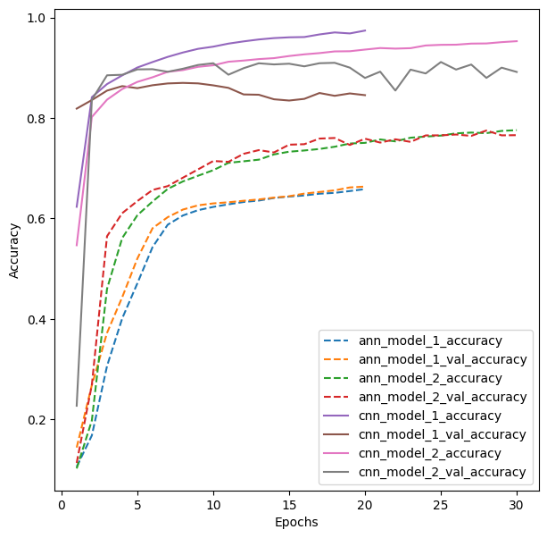

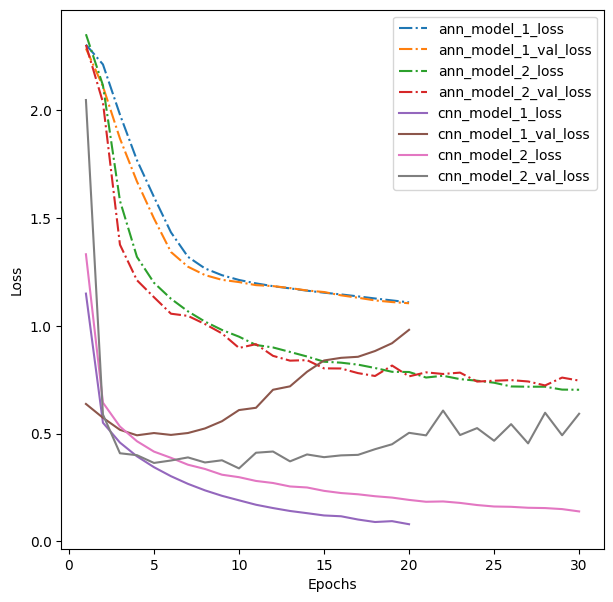

```python
#Plot training and validation accuracies and loss
dict_hist_4 = fit_history_4.history

list_epoch = [i for i in range(1,21)]
list_epoch_2 = [i for i in range(1,31)]

plt.figure(figsize = (7,7))

plt.plot(list_epoch, dict_hist['accuracy'], ls = '--', label = 'ann_model_1_accuracy')
plt.plot(list_epoch, dict_hist['val_accuracy'], ls = '--', label = 'ann_model_1_val_accuracy')
plt.plot(list_epoch_2, dict_hist_2['accuracy'], ls = '--', label = 'ann_model_2_accuracy')
plt.plot(list_epoch_2, dict_hist_2['val_accuracy'], ls = '--', label = 'ann_model_2_val_accuracy')
plt.plot(list_epoch, dict_hist_3['accuracy'], label = 'cnn_model_1_accuracy')
plt.plot(list_epoch, dict_hist_3['val_accuracy'], label = 'cnn_model_1_val_accuracy')
plt.plot(list_epoch_2, dict_hist_4['accuracy'], label = 'cnn_model_2_accuracy')
plt.plot(list_epoch_2, dict_hist_4['val_accuracy'], label = 'cnn_model_2_val_accuracy')

plt.ylabel('Accuracy')
plt.xlabel('Epochs')
plt.legend()
plt.show()

plt.figure(figsize=(7,7))
plt.plot(list_epoch, dict_hist['loss'], ls = '-.', label = 'ann_model_1_loss')
plt.plot(list_epoch, dict_hist['val_loss'], ls = '-.', label = 'ann_model_1_val_loss')
plt.plot(list_epoch_2, dict_hist_2['loss'], ls = '-.',label = 'ann_model_2_loss')
plt.plot(list_epoch_2, dict_hist_2['val_loss'], ls = '-.',label = 'ann_model_2_val_loss')
plt.plot(list_epoch, dict_hist_3['loss'], label = 'cnn_model_1_loss')
plt.plot(list_epoch, dict_hist_3['val_loss'], label = 'cnn_model_1_val_loss')
plt.plot(list_epoch_2, dict_hist_4['loss'], label = 'cnn_model_2_loss')
plt.plot(list_epoch_2, dict_hist_4['val_loss'], label = 'cnn_model_2_val_loss')

plt.ylabel('Loss')
plt.xlabel('Epochs')
plt.legend()
plt.show()
```

**Observations:________**

1. The second CNN has an accuracy of 95% after 30 epochs on the training data. This is slightly lower that the accuracy on training for the first CNN which was 97%. However the second CNN, generalizes better on validation data attaining an accuracy of 89% compared to the first CNN which performed poorly on validation with an accuracy of 85%.
2. Adding drop out layers and batch normalization to the CNN improved its perfomance on unseen data.
3. The second CNN is the best model in terms of accuracy on the validation data set.
4. However, we see the validation loss increasing with epochs for the second CNN suggesting that the model is still overfitting slightly.

## **Predictions on the test data**

- Make predictions on the test set using the second model.
- Print the obtained results using the classification report and the confusion matrix.
- Final observations on the obtained results.

```python
#Evaluate model accuracy on test data
cnn_model_2.evaluate(X_test, Y_test, verbose = 1)
cnn_model_2_test_pred = np.argmax(cnn_model_2.predict(X_test), axis=-1)
cnn_model_2_test_pred
```

```
563/563 ━━━━━━━━━━━━━━━━━━━━ 18s 32ms/step - accuracy: 0.8932 - loss: 0.5863
563/563 ━━━━━━━━━━━━━━━━━━━━ 18s 32ms/step
```

```
array([8, 7, 2, ..., 7, 8, 2])
```

The accuracy of the second CNN on test data is 89%. This is the best model in terms of accuracy on test data.

### **Make predictions on the test data using the second model.**

**Note:** Earlier, we noticed that each entry of the target variable is a one-hot encoded vector, but to print the classification report and confusion matrix, we must convert each entry of y_test to a single label.

```
              precision    recall  f1-score   support

           0       0.88      0.94      0.91      1814
           1       0.88      0.89      0.89      1828
           2       0.95      0.87      0.91      1803
           3       0.89      0.86      0.87      1719
           4       0.93      0.88      0.91      1812
           5       0.89      0.89      0.89      1768
           6       0.84      0.89      0.86      1832
           7       0.93      0.89      0.91      1808
           8       0.84      0.90      0.87      1812
           9       0.88      0.89      0.88      1804

    accuracy                           0.89     18000
   macro avg       0.89      0.89      0.89     18000
weighted avg       0.89      0.89      0.89     18000
```

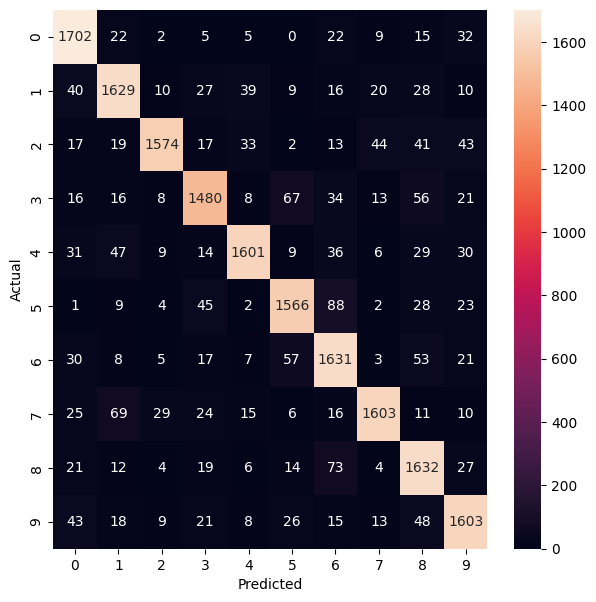

```python
#Publish the confusion matrix
metrics_score(y_test,cnn_model_2_test_pred)
```

#### Observations

1. The second CNN model is the best street level classification model. We see the best accuracy on test data of 89%. This model classifies correctly all digits, we see the largest values in the diagonal that we have seen of any model trained so far.
2. Digits 8, 6, and 3 have the lowest f1-scores. These digits are easily misclassified.
3. Digits 0, 2, 4, and 7 have the highest f1-scores and are classified correctly most of the time.
4. Actual number 8 is often misclassified often as number 6. Actual number 6 is misclassified often as numbers 5 or 8.

#### Let us visualize 24 images from the test data and their classification

[output not shown]

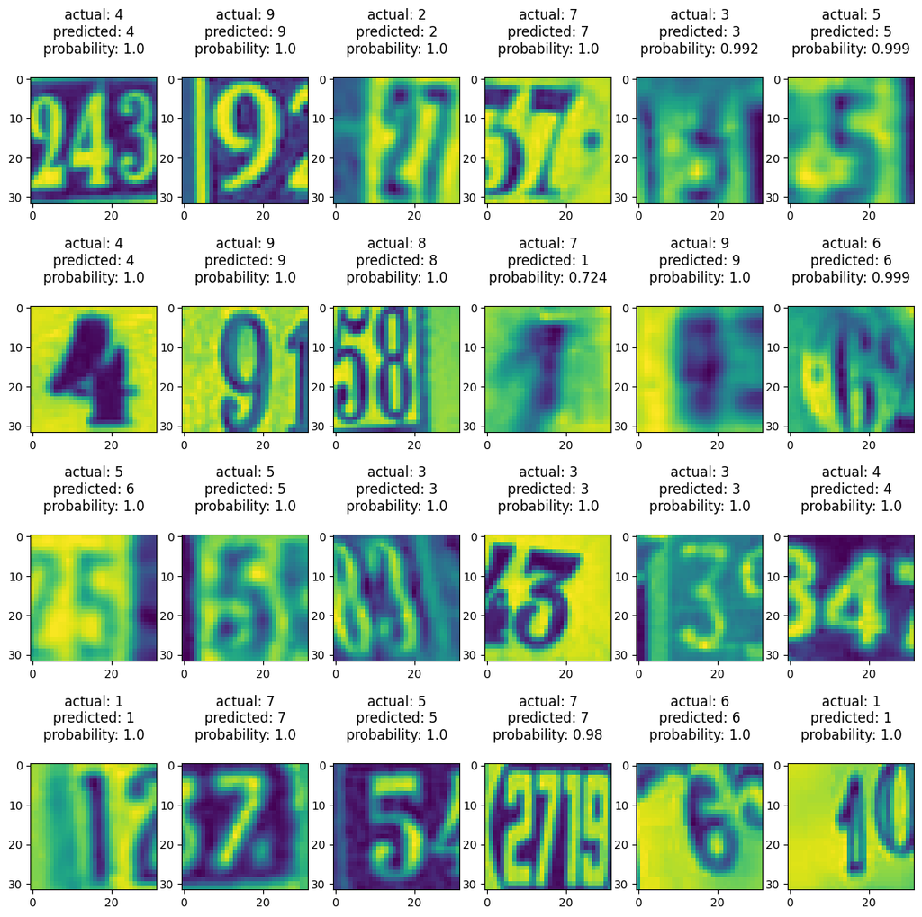

```python
#Visualize images from the test data, their true values and the classification by the model
rows = 4
cols = 6

fig = plt.figure(figsize=(14,14))
for i in range(cols):
  for j in range(rows):
    random_index = np.random.randint(0, len(Y_test))
    ax = fig.add_subplot(rows,cols,i*rows+j+1)
    ax.imshow(x_test[random_index,:])
    pred_label = unique_categories_list[cnn_model_2_test_pred[random_index]]
    true_label = unique_categories_list[y_test[random_index]]
    y_pred_test_cnn_model_2_max_probas = np.max(cnn_model_2.predict(X_test), axis=1)
    pred_proba = y_pred_test_cnn_model_2_max_probas[random_index]

    ax.set_title("actual: {}\npredicted: {}\nprobability: {:.3}\n".format(
        true_label, pred_label, pred_proba
    ))

plt.show()
```

### **Write your final observations on the performance of the model on the test data.**

**Final Observations:_________**

1. The second CNN model gives the best accuracy in terms of predicting the correct number in street level pictures of numbers. This model takes the longest to train (1 hour and 15 minutes) and so more compute resources and time are the trade-offs for accuracy
2. We observe that the 2nd CNN is slightly overfitting to the training data, the loss increases on the validation data set for the later epochs.
3. The convolutional neural networks performed better in terms of accuracy compared to the artificial neural networks.
4. Although the CNNs give higher accuracy for image classification, they take longer to train.

**Recommendations:_________**

1. The second CNN model is the best model in terms of accuracy and is recommended for use for street level digit classification although the model should be improved for efficiency. ** Efficiency improvement strategies could include:**
- Experimenting with additional dropout layers and early stopping to prevent overfitting to training data.
- Examine if a slightly simpler model could achieve similar accuracy while resulting in faster training time.
- One can try different activation functions to see if accuracy could be improved.

```python
#Convert notebook to html
!jupyter nbconvert --to html '/content/drive/MyDrive/MachineLearningCourse/ElectiveProject_DeepLearning/High_Code_SVHN_Digit_Recognition_MoureenKemei.ipynb'
```

```
[NbConvertApp] Converting notebook /content/drive/MyDrive/MachineLearningCourse/ElectiveProject_DeepLearning/High_Code_SVHN_Digit_Recognition_MoureenKemei.ipynb to html
[NbConvertApp] WARNING | Alternative text is missing on 16 image(s).
[NbConvertApp] Writing 2120665 bytes to /content/drive/MyDrive/MachineLearningCourse/ElectiveProject_DeepLearning/High_Code_SVHN_Digit_Recognition_MoureenKemei.html
```